# Project: Identify Customer Segments

In this project, you will apply unsupervised learning techniques to identify segments of the population that form the core customer base for a mail-order sales company in Germany. These segments can then be used to direct marketing campaigns towards audiences that will have the highest expected rate of returns. The data that you will use has been provided by our partners at Bertelsmann Arvato Analytics, and represents a real-life data science task.

This notebook will help you complete this task by providing a framework within which you will perform your analysis steps. In each step of the project, you will see some text describing the subtask that you will perform, followed by one or more code cells for you to complete your work. **Feel free to add additional code and markdown cells as you go along so that you can explore everything in precise chunks.** The code cells provided in the base template will outline only the major tasks, and will usually not be enough to cover all of the minor tasks that comprise it.

It should be noted that while there will be precise guidelines on how you should handle certain tasks in the project, there will also be places where an exact specification is not provided. **There will be times in the project where you will need to make and justify your own decisions on how to treat the data.** These are places where there may not be only one way to handle the data. In real-life tasks, there may be many valid ways to approach an analysis task. One of the most important things you can do is clearly document your approach so that other scientists can understand the decisions you've made.

At the end of most sections, there will be a Markdown cell labeled **Discussion**. In these cells, you will report your findings for the completed section, as well as document the decisions that you made in your approach to each subtask. **Your project will be evaluated not just on the code used to complete the tasks outlined, but also your communication about your observations and conclusions at each stage.**

```python
# import libraries here; add more as necessary
import numpy as np
import pandas as pd
import matplotlib.pyplot as plt
import seaborn as sns
from sklearn.preprocessing import Imputer
from sklearn.preprocessing import StandardScaler
from sklearn.decomposition import PCA
from sklearn.cluster import KMeans

# magic word for producing visualizations in notebook
%matplotlib inline

'''
Import note: The classroom currently uses sklearn version 0.19.
If you need to use an imputer, it is available in sklearn.preprocessing.Imputer,
instead of sklearn.impute as in newer versions of sklearn.
'''
```

```
'\nImport note: The classroom currently uses sklearn version 0.19.\nIf you need to use an imputer, it is available in sklearn.preprocessing.Imputer,\ninstead of sklearn.impute as in newer versions of sklearn.\n'
```

### Step 0: Load the Data

There are four files associated with this project (not including this one):

Each row of the demographics files represents a single person, but also includes information outside of individuals, including information about their household, building, and neighborhood. You will use this information to cluster the general population into groups with similar demographic properties. Then, you will see how the people in the customers dataset fit into those created clusters. The hope here is that certain clusters are over-represented in the customers data, as compared to the general population; those over-represented clusters will be assumed to be part of the core userbase. This information can then be used for further applications, such as targeting for a marketing campaign.

To start off with, load in the demographics data for the general population into a pandas DataFrame, and do the same for the feature attributes summary. Note for all of the `.csv` data files in this project: they're semicolon (`;`) delimited, so you'll need an additional argument in your [`read_csv()`](https://pandas.pydata.org/pandas-docs/stable/generated/pandas.read_csv.html) call to read in the data properly. Also, considering the size of the main dataset, it may take some time for it to load completely.

Once the dataset is loaded, it's recommended that you take a little bit of time just browsing the general structure of the dataset and feature summary file. You'll be getting deep into the innards of the cleaning in the first major step of the project, so gaining some general familiarity can help you get your bearings.

```python
# Load in the general demographics data.
azdias = pd.read_csv('Udacity_AZDIAS_Subset.csv', sep=';')

# Load in the feature summary file.
feat_info = pd.read_csv('AZDIAS_Feature_Summary.csv', sep=';')
```

```python
# Check the structure of the data after it's loaded (e.g. print the number of
# rows and columns, print the first few rows)
print('The number of rows in azdias is {}.'.format(azdias.shape[0]))
print('The number of columns in azdias is {}.'.format(azdias.shape[1]))
print('The number of rows in feat_info is {}.'.format(feat_info.shape[0]))
print('The number of columns in feat_info is {}.'.format(feat_info.shape[1]))
```

```
The number of rows in azdias is 891221.
The number of columns in azdias is 85.
The number of rows in feat_info is 85.
The number of columns in feat_info is 4.
```

```python
%%HTML
<style type="text/css">
table.dataframe td, table.dataframe th {
    border: 1px  black solid !important;
  color: black !important;
}
</style
```

```python
# Generate descriptive statistics of the dataset
pd.set_option('display.max_rows', 100)
azdias.describe().T
```

|  | count | mean | std | min | 25% | 50% | 75% | max |
| --- | --- | --- | --- | --- | --- | --- | --- | --- |
| AGER_TYP | 891221.0 | -0.358435 | 1.198724 | -1.0 | -1.0 | -1.0 | -1.0 | 3.0 |
| ALTERSKATEGORIE_GROB | 891221.0 | 2.777398 | 1.068775 | 1.0 | 2.0 | 3.0 | 4.0 | 9.0 |
| ANREDE_KZ | 891221.0 | 1.522098 | 0.499512 | 1.0 | 1.0 | 2.0 | 2.0 | 2.0 |
| CJT_GESAMTTYP | 886367.0 | 3.632838 | 1.595021 | 1.0 | 2.0 | 4.0 | 5.0 | 6.0 |
| FINANZ_MINIMALIST | 891221.0 | 3.074528 | 1.321055 | 1.0 | 2.0 | 3.0 | 4.0 | 5.0 |
| FINANZ_SPARER | 891221.0 | 2.821039 | 1.464749 | 1.0 | 1.0 | 3.0 | 4.0 | 5.0 |
| FINANZ_VORSORGER | 891221.0 | 3.401106 | 1.322134 | 1.0 | 3.0 | 3.0 | 5.0 | 5.0 |
| FINANZ_ANLEGER | 891221.0 | 3.033328 | 1.529603 | 1.0 | 2.0 | 3.0 | 5.0 | 5.0 |
| FINANZ_UNAUFFAELLIGER | 891221.0 | 2.874167 | 1.486731 | 1.0 | 2.0 | 3.0 | 4.0 | 5.0 |
| FINANZ_HAUSBAUER | 891221.0 | 3.075121 | 1.353248 | 1.0 | 2.0 | 3.0 | 4.0 | 5.0 |
| FINANZTYP | 891221.0 | 3.790586 | 1.987876 | 1.0 | 2.0 | 4.0 | 6.0 | 6.0 |
| GEBURTSJAHR | 891221.0 | 1101.178533 | 976.583551 | 0.0 | 0.0 | 1943.0 | 1970.0 | 2017.0 |
| GFK_URLAUBERTYP | 886367.0 | 7.350304 | 3.525723 | 1.0 | 5.0 | 8.0 | 10.0 | 12.0 |
| GREEN_AVANTGARDE | 891221.0 | 0.196612 | 0.397437 | 0.0 | 0.0 | 0.0 | 0.0 | 1.0 |
| HEALTH_TYP | 891221.0 | 1.792102 | 1.269062 | -1.0 | 1.0 | 2.0 | 3.0 | 3.0 |
| LP_LEBENSPHASE_FEIN | 886367.0 | 14.622637 | 12.616883 | 0.0 | 4.0 | 11.0 | 27.0 | 40.0 |
| LP_LEBENSPHASE_GROB | 886367.0 | 4.453621 | 3.855639 | 0.0 | 1.0 | 3.0 | 8.0 | 12.0 |
| LP_FAMILIE_FEIN | 886367.0 | 3.599574 | 3.926486 | 0.0 | 1.0 | 1.0 | 8.0 | 11.0 |
| LP_FAMILIE_GROB | 886367.0 | 2.185966 | 1.756537 | 0.0 | 1.0 | 1.0 | 4.0 | 5.0 |
| LP_STATUS_FEIN | 886367.0 | 4.791151 | 3.425305 | 1.0 | 2.0 | 4.0 | 9.0 | 10.0 |
| LP_STATUS_GROB | 886367.0 | 2.432575 | 1.474315 | 1.0 | 1.0 | 2.0 | 4.0 | 5.0 |
| NATIONALITAET_KZ | 891221.0 | 1.026827 | 0.586634 | 0.0 | 1.0 | 1.0 | 1.0 | 3.0 |
| PRAEGENDE_JUGENDJAHRE | 891221.0 | 8.154346 | 4.844532 | 0.0 | 5.0 | 8.0 | 14.0 | 15.0 |
| RETOURTYP_BK_S | 886367.0 | 3.419630 | 1.417741 | 1.0 | 2.0 | 3.0 | 5.0 | 5.0 |
| SEMIO_SOZ | 891221.0 | 3.945860 | 1.946564 | 1.0 | 2.0 | 4.0 | 6.0 | 7.0 |
| SEMIO_FAM | 891221.0 | 4.272729 | 1.915885 | 1.0 | 3.0 | 4.0 | 6.0 | 7.0 |
| SEMIO_REL | 891221.0 | 4.240609 | 2.007373 | 1.0 | 3.0 | 4.0 | 6.0 | 7.0 |
| SEMIO_MAT | 891221.0 | 4.001597 | 1.857540 | 1.0 | 2.0 | 4.0 | 5.0 | 7.0 |
| SEMIO_VERT | 891221.0 | 4.023709 | 2.077746 | 1.0 | 2.0 | 4.0 | 6.0 | 7.0 |
| SEMIO_LUST | 891221.0 | 4.359086 | 2.022829 | 1.0 | 2.0 | 5.0 | 6.0 | 7.0 |

[output cut: 51 more lines]

```python
feat_info.describe()
```

|  | attribute | information_level | type | missing_or_unknown |
| --- | --- | --- | --- | --- |
| count | 85 | 85 | 85 | 85 |
| unique | 85 | 9 | 5 | 9 |
| top | HEALTH_TYP | person | ordinal | [-1] |
| freq | 1 | 43 | 49 | 26 |

```python
feat_info.info()
```

```
<class 'pandas.core.frame.DataFrame'>
RangeIndex: 85 entries, 0 to 84
Data columns (total 4 columns):
attribute             85 non-null object
information_level     85 non-null object
type                  85 non-null object
missing_or_unknown    85 non-null object
dtypes: object(4)
memory usage: 2.7+ KB
```

```python
feat_info.head(85)
```

|  | attribute | information_level | type | missing_or_unknown |
| --- | --- | --- | --- | --- |
| 0 | AGER_TYP | person | categorical | [-1,0] |
| 1 | ALTERSKATEGORIE_GROB | person | ordinal | [-1,0,9] |
| 2 | ANREDE_KZ | person | categorical | [-1,0] |
| 3 | CJT_GESAMTTYP | person | categorical | [0] |
| 4 | FINANZ_MINIMALIST | person | ordinal | [-1] |
| 5 | FINANZ_SPARER | person | ordinal | [-1] |
| 6 | FINANZ_VORSORGER | person | ordinal | [-1] |
| 7 | FINANZ_ANLEGER | person | ordinal | [-1] |
| 8 | FINANZ_UNAUFFAELLIGER | person | ordinal | [-1] |
| 9 | FINANZ_HAUSBAUER | person | ordinal | [-1] |
| 10 | FINANZTYP | person | categorical | [-1] |
| 11 | GEBURTSJAHR | person | numeric | [0] |
| 12 | GFK_URLAUBERTYP | person | categorical | [] |
| 13 | GREEN_AVANTGARDE | person | categorical | [] |
| 14 | HEALTH_TYP | person | ordinal | [-1,0] |
| 15 | LP_LEBENSPHASE_FEIN | person | mixed | [0] |
| 16 | LP_LEBENSPHASE_GROB | person | mixed | [0] |
| 17 | LP_FAMILIE_FEIN | person | categorical | [0] |
| 18 | LP_FAMILIE_GROB | person | categorical | [0] |
| 19 | LP_STATUS_FEIN | person | categorical | [0] |
| 20 | LP_STATUS_GROB | person | categorical | [0] |
| 21 | NATIONALITAET_KZ | person | categorical | [-1,0] |
| 22 | PRAEGENDE_JUGENDJAHRE | person | mixed | [-1,0] |
| 23 | RETOURTYP_BK_S | person | ordinal | [0] |
| 24 | SEMIO_SOZ | person | ordinal | [-1,9] |
| 25 | SEMIO_FAM | person | ordinal | [-1,9] |
| 26 | SEMIO_REL | person | ordinal | [-1,9] |
| 27 | SEMIO_MAT | person | ordinal | [-1,9] |
| 28 | SEMIO_VERT | person | ordinal | [-1,9] |
| 29 | SEMIO_LUST | person | ordinal | [-1,9] |

[output cut: 55 more lines]

> **Tip**: Add additional cells to keep everything in reasonably-sized chunks! Keyboard shortcut `esc --> a` (press escape to enter command mode, then press the 'A' key) adds a new cell before the active cell, and `esc --> b` adds a new cell after the active cell. If you need to convert an active cell to a markdown cell, use `esc --> m` and to convert to a code cell, use `esc --> y`.

## Step 1: Preprocessing

### Step 1.1: Assess Missing Data

The feature summary file contains a summary of properties for each demographics data column. You will use this file to help you make cleaning decisions during this stage of the project. First of all, you should assess the demographics data in terms of missing data. Pay attention to the following points as you perform your analysis, and take notes on what you observe. Make sure that you fill in the **Discussion** cell with your findings and decisions at the end of each step that has one!

#### Step 1.1.1: Convert Missing Value Codes to NaNs

The fourth column of the feature attributes summary (loaded in above as `feat_info`) documents the codes from the data dictionary that indicate missing or unknown data. While the file encodes this as a list (e.g. `[-1,0]`), this will get read in as a string object. You'll need to do a little bit of parsing to make use of it to identify and clean the data. Convert data that matches a 'missing' or 'unknown' value code into a numpy NaN value. You might want to see how much data takes on a 'missing' or 'unknown' code, and how much data is naturally missing, as a point of interest.

**As one more reminder, you are encouraged to add additional cells to break up your analysis into manageable chunks.**

```python
# Identify missing or unknown data values and convert them to NaNs.

column_names = ['NANs Before', 'NANs After']
df_missing_vals = pd.DataFrame(columns = column_names)

# column names
ind = []

for i in range(azdias.shape[1]):
    clm = feat_info['attribute'][i]
    NaN_original = azdias[clm].isnull().sum()

    missing_lst = feat_info['missing_or_unknown'][i]
    missing_lst = missing_lst.split(',')

    if missing_lst != '':

        for val in missing_lst:
            val = val.strip('[')
            val = val.strip(']')

            try:
                val = int(val)
            except:
                pass

            azdias[clm].replace(val,np.NaN, inplace = True)
    NaN_end = azdias[clm].isnull().sum()

    if NaN_original < NaN_end:
        df_missing_vals.loc[len(df_missing_vals)] = [NaN_original, NaN_end]
        ind.append(clm)
        print('{}: NaNs before processing: {} NaNs after processing: {}'.format(clm, NaN_original, NaN_end))
```

```
AGER_TYP: NaNs before processing: 0 NaNs after processing: 685843
ALTERSKATEGORIE_GROB: NaNs before processing: 0 NaNs after processing: 2881
GEBURTSJAHR: NaNs before processing: 0 NaNs after processing: 392318
HEALTH_TYP: NaNs before processing: 0 NaNs after processing: 111196
LP_LEBENSPHASE_FEIN: NaNs before processing: 4854 NaNs after processing: 97632
LP_LEBENSPHASE_GROB: NaNs before processing: 4854 NaNs after processing: 94572
LP_FAMILIE_FEIN: NaNs before processing: 4854 NaNs after processing: 77792
LP_FAMILIE_GROB: NaNs before processing: 4854 NaNs after processing: 77792
NATIONALITAET_KZ: NaNs before processing: 0 NaNs after processing: 108315
PRAEGENDE_JUGENDJAHRE: NaNs before processing: 0 NaNs after processing: 108164
SHOPPER_TYP: NaNs before processing: 0 NaNs after processing: 111196
TITEL_KZ: NaNs before processing: 73499 NaNs after processing: 889061
VERS_TYP: NaNs before processing: 0 NaNs after processing: 111196
ALTER_HH: NaNs before processing: 73499 NaNs after processing: 310267
W_KEIT_KIND_HH: NaNs before processing: 107602 NaNs after processing: 147988
ANZ_HAUSHALTE_AKTIV: NaNs before processing: 93148 NaNs after processing: 99611
CAMEO_DEUG_2015: NaNs before processing: 98979 NaNs after processing: 99352
CAMEO_DEU_2015: NaNs before processing: 98979 NaNs after processing: 99352
CAMEO_INTL_2015: NaNs before processing: 98979 NaNs after processing: 99352
KBA05_BAUMAX: NaNs before processing: 133324 NaNs after processing: 476524
KKK: NaNs before processing: 121196 NaNs after processing: 158064
REGIOTYP: NaNs before processing: 121196 NaNs after processing: 158064
ARBEIT: NaNs before processing: 97216 NaNs after processing: 97375
ORTSGR_KLS9: NaNs before processing: 97216 NaNs after processing: 97274
RELAT_AB: NaNs before processing: 97216 NaNs after processing: 97375
```

```python
df_missing_vals.index = ind
df_missing_vals
```

|  | NANs Before | NANs After |
| --- | --- | --- |
| AGER_TYP | 0 | 685843 |
| ALTERSKATEGORIE_GROB | 0 | 2881 |
| GEBURTSJAHR | 0 | 392318 |
| HEALTH_TYP | 0 | 111196 |
| LP_LEBENSPHASE_FEIN | 4854 | 97632 |
| LP_LEBENSPHASE_GROB | 4854 | 94572 |
| LP_FAMILIE_FEIN | 4854 | 77792 |
| LP_FAMILIE_GROB | 4854 | 77792 |
| NATIONALITAET_KZ | 0 | 108315 |
| PRAEGENDE_JUGENDJAHRE | 0 | 108164 |
| SHOPPER_TYP | 0 | 111196 |
| TITEL_KZ | 73499 | 889061 |
| VERS_TYP | 0 | 111196 |
| ALTER_HH | 73499 | 310267 |
| W_KEIT_KIND_HH | 107602 | 147988 |
| ANZ_HAUSHALTE_AKTIV | 93148 | 99611 |
| CAMEO_DEUG_2015 | 98979 | 99352 |
| CAMEO_DEU_2015 | 98979 | 99352 |
| CAMEO_INTL_2015 | 98979 | 99352 |
| KBA05_BAUMAX | 133324 | 476524 |
| KKK | 121196 | 158064 |
| REGIOTYP | 121196 | 158064 |
| ARBEIT | 97216 | 97375 |
| ORTSGR_KLS9 | 97216 | 97274 |
| RELAT_AB | 97216 | 97375 |

#### Step 1.1.2: Assess Missing Data in Each Column

How much missing data is present in each column? There are a few columns that are outliers in terms of the proportion of values that are missing. You will want to use matplotlib's [`hist()`](https://matplotlib.org/api/_as_gen/matplotlib.pyplot.hist.html) function to visualize the distribution of missing value counts to find these columns. Identify and document these columns. While some of these columns might have justifications for keeping or re-encoding the data, for this project you should just remove them from the dataframe. (Feel free to make remarks about these outlier columns in the discussion, however!)

For the remaining features, are there any patterns in which columns have, or share, missing data?

```python
# Perform an assessment of how much missing data there is in each column of the
# dataset.
miss_vals_col = azdias.isna().sum()
miss_vals_col_ratio = miss_vals_col.sort_values(ascending=False) / len(azdias)
```

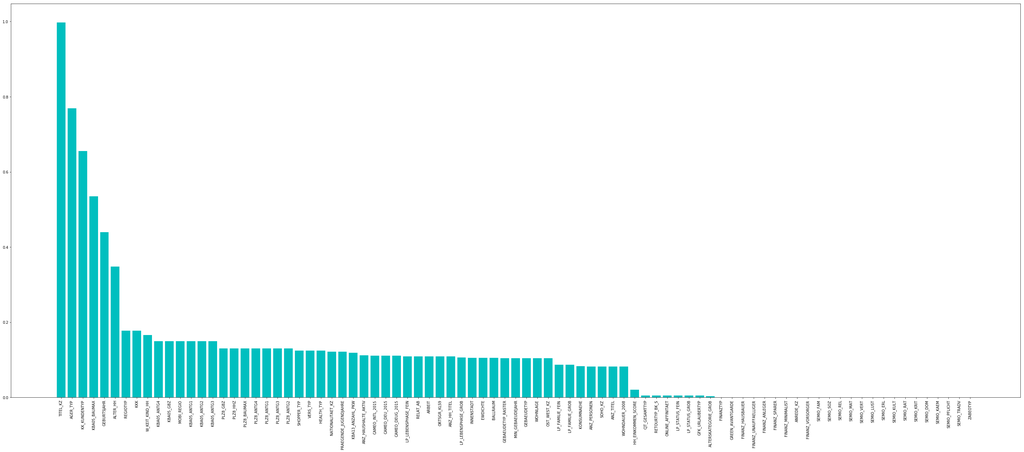

```python
# use bar plot to display the proportion of missing data in all columns

x = range(len(miss_vals_col_ratio))
y = miss_vals_col_ratio

labels = miss_vals_col_ratio.index
plt.figure(figsize=(50,20))
ax = plt.subplot()
ax.set_xticks(x)
ax.set_xticklabels(labels)
plt.setp(ax.xaxis.get_majorticklabels(), rotation=90)

plt.bar(x, y, color='c')
plt.show()
```

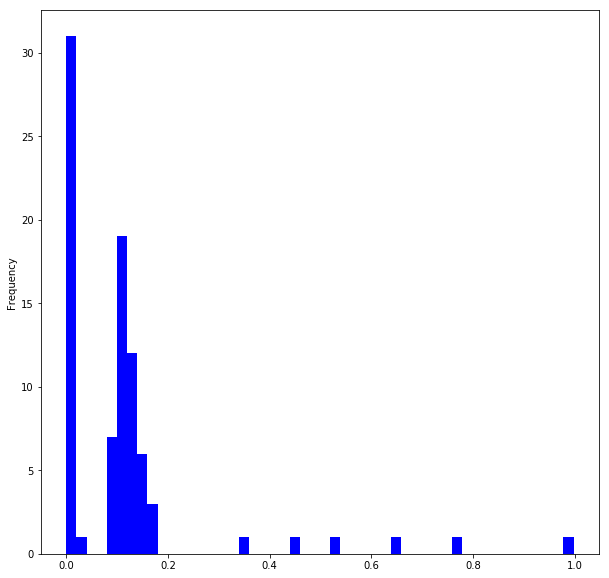

```python
# Investigate patterns in the amount of missing data in each column.
plt.figure(figsize=(10,10))
miss_vals_col_ratio.plot.hist(color='b', bins=50)
plt.show()
```

```python
display(miss_vals_col_ratio)
```

```
TITEL_KZ                 0.997576
AGER_TYP                 0.769554
KK_KUNDENTYP             0.655967
KBA05_BAUMAX             0.534687
GEBURTSJAHR              0.440203
ALTER_HH                 0.348137
REGIOTYP                 0.177357
KKK                      0.177357
W_KEIT_KIND_HH           0.166051
KBA05_ANTG4              0.149597
KBA05_GBZ                0.149597
MOBI_REGIO               0.149597
KBA05_ANTG1              0.149597
KBA05_ANTG2              0.149597
KBA05_ANTG3              0.149597
PLZ8_GBZ                 0.130736
PLZ8_HHZ                 0.130736
PLZ8_BAUMAX              0.130736
PLZ8_ANTG4               0.130736
PLZ8_ANTG1               0.130736
PLZ8_ANTG3               0.130736
PLZ8_ANTG2               0.130736
SHOPPER_TYP              0.124768
VERS_TYP                 0.124768
HEALTH_TYP               0.124768
NATIONALITAET_KZ         0.121536
PRAEGENDE_JUGENDJAHRE    0.121366
KBA13_ANZAHL_PKW         0.118714
ANZ_HAUSHALTE_AKTIV      0.111769
CAMEO_INTL_2015          0.111479
                           ...
RETOURTYP_BK_S           0.005446
ONLINE_AFFINITAET        0.005446
LP_STATUS_FEIN           0.005446
LP_STATUS_GROB           0.005446
GFK_URLAUBERTYP          0.005446
ALTERSKATEGORIE_GROB     0.003233
FINANZTYP                0.000000
GREEN_AVANTGARDE         0.000000
FINANZ_HAUSBAUER         0.000000
FINANZ_UNAUFFAELLIGER    0.000000
FINANZ_ANLEGER           0.000000
FINANZ_SPARER            0.000000
FINANZ_MINIMALIST        0.000000
ANREDE_KZ                0.000000
FINANZ_VORSORGER         0.000000
SEMIO_FAM                0.000000
SEMIO_SOZ                0.000000
SEMIO_REL                0.000000
SEMIO_MAT                0.000000
SEMIO_VERT               0.000000
SEMIO_LUST               0.000000
SEMIO_ERL                0.000000
SEMIO_KULT               0.000000
SEMIO_RAT                0.000000
SEMIO_KRIT               0.000000
SEMIO_DOM                0.000000
SEMIO_KAEM               0.000000
SEMIO_PFLICHT            0.000000
SEMIO_TRADV              0.000000
ZABEOTYP                 0.000000
Length: 85, dtype: float64
```

```python
# The top six columns in 'miss_vals_col_ratio' clearly differ significantly from the rest of the columns and they are also
# shown in the histogram as outliers in terms of the amount of missing data.
```

```python
# Based on the histogram, the outlier columns have a ratio of missing values that is greater than 0.2
#How many columns have 0.2 or less of their contents missing
len(miss_vals_col_ratio[miss_vals_col_ratio <= 0.2])
```

```
79
```

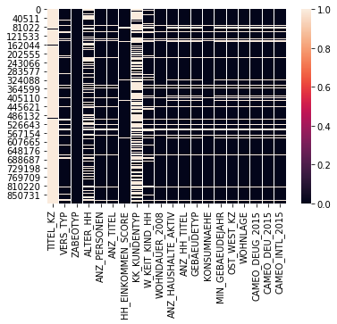

```python
# Investigate patterns in the amount of missing data in each column.

test = azdias.isnull().iloc[:, 40:60]
sns.heatmap(test)
```

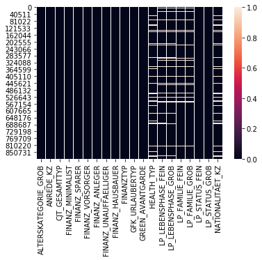

```python
test = azdias.isnull().iloc[:,:20]
sns.heatmap(test)
```

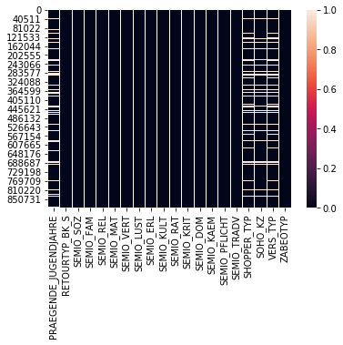

```python
test = azdias.isnull().iloc[:,20:40]
sns.heatmap(test)
```

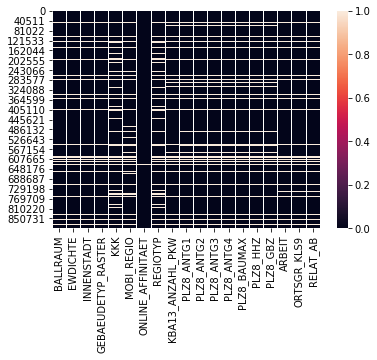

```python
test = azdias.isnull().iloc[:,60:85]
sns.heatmap(test)
```

```python
# Remove the outlier columns from the dataset.
#You'll perform other data engineering tasks such as re-encoding and imputation later.
new_feat_info = feat_info.copy()

dropped_clms = miss_vals_col_ratio[miss_vals_col_ratio > 0.2].index
for clm in miss_vals_col_ratio[miss_vals_col_ratio > 0.2].index:
    azdias.drop(clm, axis=1, inplace=True)
    indexNames = new_feat_info[ new_feat_info['attribute'] == clm ].index
    new_feat_info.drop(indexNames, inplace=True)
    print('{} dropped'.format(clm))

dropped_clms = miss_vals_col_ratio[miss_vals_col_ratio > 0.2].index
```

```
TITEL_KZ dropped
AGER_TYP dropped
KK_KUNDENTYP dropped
KBA05_BAUMAX dropped
GEBURTSJAHR dropped
ALTER_HH dropped
```

#### Discussion 1.1.2: Assess Missing Data in Each Column

As shown earlier, many columns needes processing to show exactly how much missing data they had. Up to 25 columns had the NaNs increase after the processing was applied to identify missing data based on the feat_info dataframe.

After an analysis of the missing data in each column, it was found the the following columns had more than 20% of their data missing and they were outliers compared to the rest of the columns: 'TITEL_KZ': 99.8% , 'AGER_TYP': 77.0%, 'KK_KUNDENTYP': 65.6%, 'KBA05_BAUMAX': 53.5%, 'GEBURTSJAHR': 44.0%, 'ALTER_HH': 34.8%. These six columns were deleted because of the high number of missing information.

Looking at the heatmaps, it appears that many of the columns are missing values in the same rows. This points to the fact that some examples are not going to be helpful for our clustering algorithms. Certain groups of columns are missing the same number of values as elaborated next.

The following columns have no missing data: FINANZTYP, GREEN_AVANTGARDE, FINANZ_HAUSBAUER, FINANZ_UNAUFFAELLIGER, FINANZ_ANLEGER, FINANZ_SPARER, FINANZ_MINIMALIST, ANREDE_KZ, FINANZ_VORSORGER, SEMIO_FAM, SEMIO_SOZ, SEMIO_REL, SEMIO_MAT, SEMIO_VERT, SEMIO_LUST, SEMIO_ERL, SEMIO_KULT,SEMIO_RAT, SEMIO_KRIT, SEMIO_DOM, SEMIO_KAEM, SEMIO_PFLICHT, SEMIO_TRADV, ZABEOTYP

The following columns are missing 0.5% of their data: CJT_GESAMTTYP, RETOURTYP_BK_S, ONLINE_AFFINITAET, LP_STATUS_FEIN, LP_STATUS_GROB, GFK_URLAUBERTYP. In this group, mainly LP_STATUS_FEIN, LP_STATUS_GROB are directly related and if you do not know LP_STATUS_GROB, then you definitely do not know LP_STATUS_FEIN.

The following are missing exactly 13.1% of their data: PLZ8_GBZ, PLZ8_HHZ, PLZ8_BAUMAX, PLZ8_ANTG4, PLZ8_ANTG1, PLZ8_ANTG3, PLZ8_ANTG2. All this is information relating to a region e.g number of cars, building, 1-2 family homes etc. Therefore if you do not have data on the region, then you will not hava any of this data.

These are some of the patterns established in the data.

#### Step 1.1.3: Assess Missing Data in Each Row

Now, you'll perform a similar assessment for the rows of the dataset. How much data is missing in each row? As with the columns, you should see some groups of points that have a very different numbers of missing values. Divide the data into two subsets: one for data points that are above some threshold for missing values, and a second subset for points below that threshold.

In order to know what to do with the outlier rows, we should see if the distribution of data values on columns that are not missing data (or are missing very little data) are similar or different between the two groups. Select at least five of these columns and compare the distribution of values.

- You can use seaborn's [`countplot()`](https://seaborn.pydata.org/generated/seaborn.countplot.html) function to create a bar chart of code frequencies and matplotlib's [`subplot()`](https://matplotlib.org/api/_as_gen/matplotlib.pyplot.subplot.html) function to put bar charts for the two subplots side by side.
- To reduce repeated code, you might want to write a function that can perform this comparison, taking as one of its arguments a column to be compared.

Depending on what you observe in your comparison, this will have implications on how you approach your conclusions later in the analysis. If the distributions of non-missing features look similar between the data with many missing values and the data with few or no missing values, then we could argue that simply dropping those points from the analysis won't present a major issue. On the other hand, if the data with many missing values looks very different from the data with few or no missing values, then we should make a note on those data as special. We'll revisit these data later on. **Either way, you should continue your analysis for now using just the subset of the data with few or no missing values.**

```python
# How much data is missing in each row of the dataset?
missing_data_row = azdias.isna().sum(axis=1)
azdias.shape
#print(missing_data_row)
```

```
(891221, 79)
```

```python
zero_missing = len(missing_data_row[missing_data_row == 0])
ten_percent_missing = len(missing_data_row[missing_data_row < 7.9]) - zero_missing
twenty_percent_missing = len(missing_data_row[missing_data_row < 15.8])- zero_missing - ten_percent_missing
tot_ten_percent_missing = ten_percent_missing + zero_missing

threshold_of_10 = len(missing_data_row[missing_data_row <= 10])

print('{:.2f}% rows have no missing data.'.format(zero_missing/len(azdias)*100))
print('{:.2f}% rows have missing data of up to 10%.'.format(ten_percent_missing/len(azdias)*100))
print('{:.2f}% rows have between 10% and 20% missing data.'.format(twenty_percent_missing/len(azdias)*100))
print('\n')
print('Therefore, {:.2f}% rows have upto 10% of their data missing.'.format(tot_ten_percent_missing/len(azdias)*100))
print('\n')
print('Therefore, {:.2f}% rows have upto 10 features missing.'.format(threshold_of_10/len(azdias)*100))
```

```
69.93% rows have no missing data.
13.90% rows have missing data of up to 10%.
5.07% rows have between 10% and 20% missing data.


Therefore, 83.83% rows have upto 10% of their data missing.


Therefore, 87.54% rows have upto 10 features missing.
```

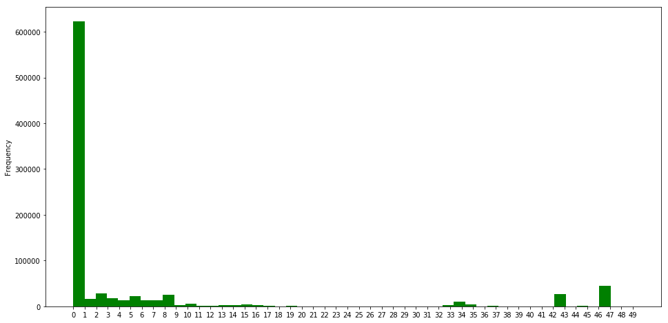

```python
plt.figure(figsize=(16,8))
plt.xticks(range(50))
missing_data_row.plot.hist(color='g', bins=50)
```

```python
# Write code to divide the data into two subsets based on the number of missing
# values in each row.
# Some authors suggest getting rid of all rows with more than 10% of the columns missing which would mean a cutoff of 7.9
# I rounded up to 8
threshold = 8
azdias_1 = azdias.copy()
azdias_low = azdias_1[missing_data_row<=threshold]
azdias_up = azdias_1[missing_data_row>threshold]

azdias_2 = azdias_low.copy()
```

```python
# Compare the distribution of values for at least five columns where there are
# no or few missing values, between the two subsets.
def clm_compare(clm):

    plt.figure(figsize=(10,5))

    plt.subplot(121)
    sns.countplot(x = clm, data=azdias_low)
    plt.title('Below Threshold Missing Rows')

    plt.subplot(122)
    sns.countplot(x = clm, data=azdias_up)
    plt.title('Above Threshold Missing Rows')

    plt.tight_layout()
```

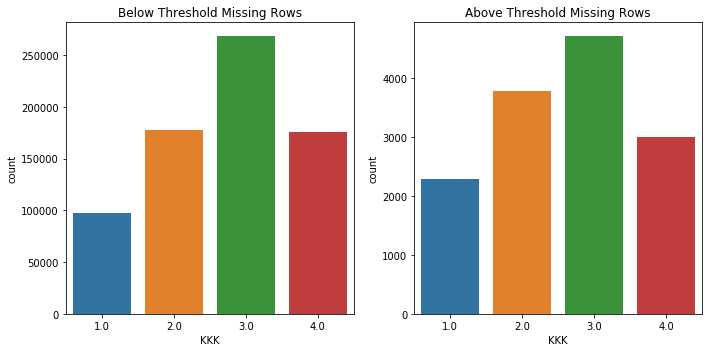

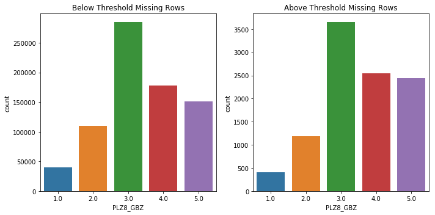

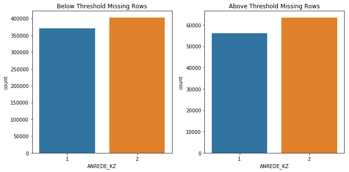

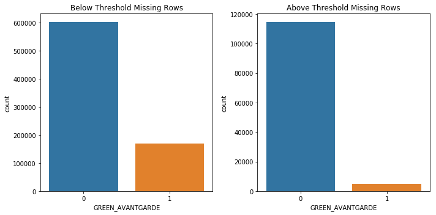

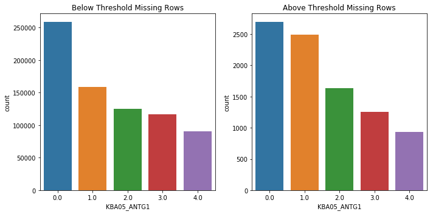

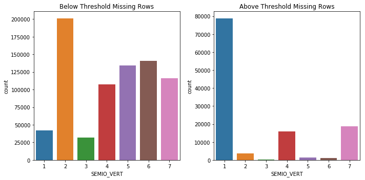

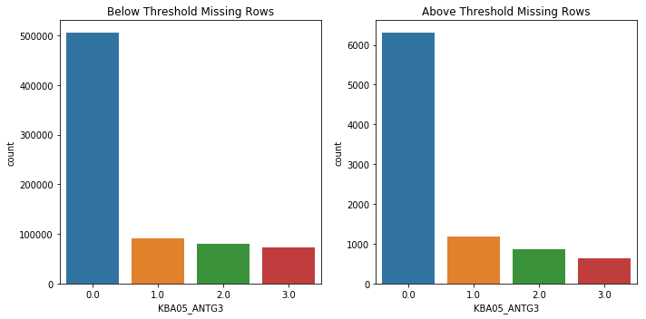

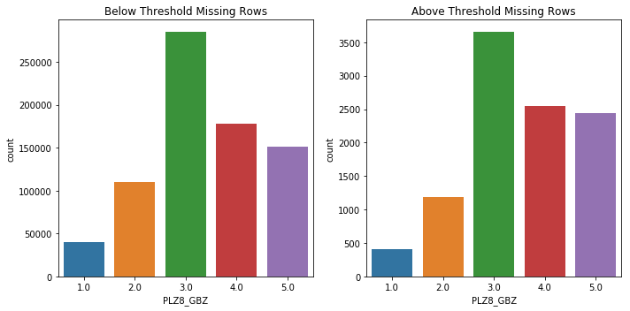

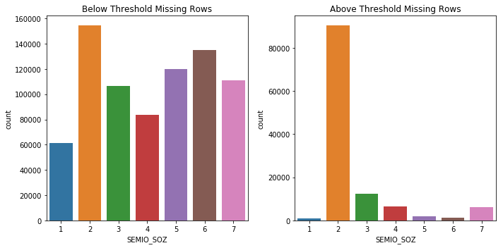

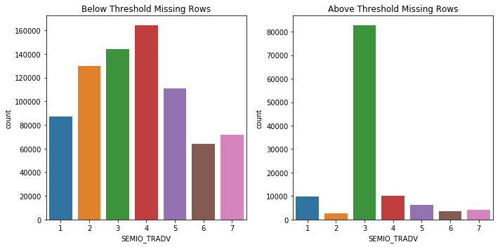

```python
for clm in np.random.choice(azdias_up.columns, 10):
    clm_compare(clm)
```

### Discussion 1.1.3: Assess Missing Data in Each Row

According [1], it is better to use data that is missing 10% or less of the features. Therefore going forward, I will use only those rows with 10% or less data missing.

[1] https://towardsdatascience.com/working-with-missing-data-in-machine-learning-9c0a430df4ce

```python
# How many features are there of each data type?
#feat_info.head()
new_feat_info.shape
new_feat_info['type'].value_counts()
```

```
ordinal        49
categorical    18
mixed           6
numeric         6
Name: type, dtype: int64
```

```python
# Info on remaining features
new_feat_info.head()
```

|  | attribute | information_level | type | missing_or_unknown |
| --- | --- | --- | --- | --- |
| 1 | ALTERSKATEGORIE_GROB | person | ordinal | [-1,0,9] |
| 2 | ANREDE_KZ | person | categorical | [-1,0] |
| 3 | CJT_GESAMTTYP | person | categorical | [0] |
| 4 | FINANZ_MINIMALIST | person | ordinal | [-1] |
| 5 | FINANZ_SPARER | person | ordinal | [-1] |

### Step 1.2: Select and Re-Encode Features

Checking for missing data isn't the only way in which you can prepare a dataset for analysis. Since the unsupervised learning techniques to be used will only work on data that is encoded numerically, you need to make a few encoding changes or additional assumptions to be able to make progress. In addition, while almost all of the values in the dataset are encoded using numbers, not all of them represent numeric values. Check the third column of the feature summary (`feat_info`) for a summary of types of measurement.

- For numeric and interval data, these features can be kept without changes.
- Most of the variables in the dataset are ordinal in nature. While ordinal values may technically be non-linear in spacing, make the simplifying assumption that the ordinal variables can be treated as being interval in nature (that is, kept without any changes).
- Special handling may be necessary for the remaining two variable types: categorical, and 'mixed'.

In the first two parts of this sub-step, you will perform an investigation of the categorical and mixed-type features and make a decision on each of them, whether you will keep, drop, or re-encode each. Then, in the last part, you will create a new data frame with only the selected and engineered columns.

Data wrangling is often the trickiest part of the data analysis process, and there's a lot of it to be done here. But stick with it: once you're done with this step, you'll be ready to get to the machine learning parts of the project!

```python
azdias_low.head()
```

|  | ALTERSKATEGORIE_GROB | ANREDE_KZ | CJT_GESAMTTYP | FINANZ_MINIMALIST | FINANZ_SPARER | FINANZ_VORSORGER | FINANZ_ANLEGER | FINANZ_UNAUFFAELLIGER | FINANZ_HAUSBAUER | FINANZTYP | ... | PLZ8_ANTG1 | PLZ8_ANTG2 | PLZ8_ANTG3 | PLZ8_ANTG4 | PLZ8_BAUMAX | PLZ8_HHZ | PLZ8_GBZ | ARBEIT | ORTSGR_KLS9 | RELAT_AB |
| --- | --- | --- | --- | --- | --- | --- | --- | --- | --- | --- | --- | --- | --- | --- | --- | --- | --- | --- | --- | --- | --- |
| 1 | 1.0 | 2 | 5.0 | 1 | 5 | 2 | 5 | 4 | 5 | 1 | ... | 2.0 | 3.0 | 2.0 | 1.0 | 1.0 | 5.0 | 4.0 | 3.0 | 5.0 | 4.0 |
| 2 | 3.0 | 2 | 3.0 | 1 | 4 | 1 | 2 | 3 | 5 | 1 | ... | 3.0 | 3.0 | 1.0 | 0.0 | 1.0 | 4.0 | 4.0 | 3.0 | 5.0 | 2.0 |
| 3 | 4.0 | 2 | 2.0 | 4 | 2 | 5 | 2 | 1 | 2 | 6 | ... | 2.0 | 2.0 | 2.0 | 0.0 | 1.0 | 3.0 | 4.0 | 2.0 | 3.0 | 3.0 |
| 4 | 3.0 | 1 | 5.0 | 4 | 3 | 4 | 1 | 3 | 2 | 5 | ... | 2.0 | 4.0 | 2.0 | 1.0 | 2.0 | 3.0 | 3.0 | 4.0 | 6.0 | 5.0 |
| 5 | 1.0 | 2 | 2.0 | 3 | 1 | 5 | 2 | 2 | 5 | 2 | ... | 2.0 | 3.0 | 1.0 | 1.0 | 1.0 | 5.0 | 5.0 | 2.0 | 3.0 | 3.0 |

5 rows × 79 columns

```python
#Columns with categorical data
cat_clms = new_feat_info[(new_feat_info.type=='categorical').values].attribute.values
print(cat_clms)
```

```
['ANREDE_KZ' 'CJT_GESAMTTYP' 'FINANZTYP' 'GFK_URLAUBERTYP'
 'GREEN_AVANTGARDE' 'LP_FAMILIE_FEIN' 'LP_FAMILIE_GROB' 'LP_STATUS_FEIN'
 'LP_STATUS_GROB' 'NATIONALITAET_KZ' 'SHOPPER_TYP' 'SOHO_KZ' 'VERS_TYP'
 'ZABEOTYP' 'GEBAEUDETYP' 'OST_WEST_KZ' 'CAMEO_DEUG_2015' 'CAMEO_DEU_2015']
```

#### Step 1.2.1: Re-Encode Categorical Features

For categorical data, you would ordinarily need to encode the levels as dummy variables. Depending on the number of categories, perform one of the following:

- For binary (two-level) categoricals that take numeric values, you can keep them without needing to do anything.
- There is one binary variable that takes on non-numeric values. For this one, you need to re-encode the values as numbers or create a dummy variable.
- For multi-level categoricals (three or more values), you can choose to encode the values using multiple dummy variables (e.g. via [OneHotEncoder](http://scikit-learn.org/stable/modules/generated/sklearn.preprocessing.OneHotEncoder.html)), or (to keep things straightforward) just drop them from the analysis. As always, document your choices in the Discussion section.

```
ANREDE_KZ
```

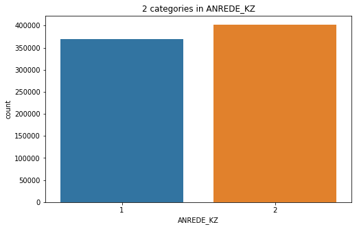

```
CJT_GESAMTTYP
```

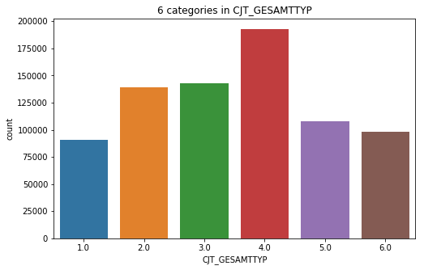

```
FINANZTYP
```

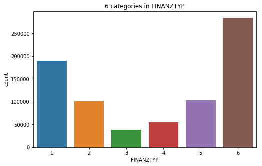

```
GFK_URLAUBERTYP
```

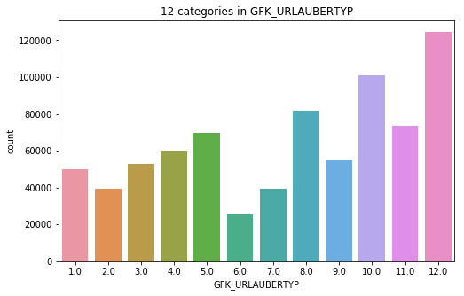

```
GREEN_AVANTGARDE
```

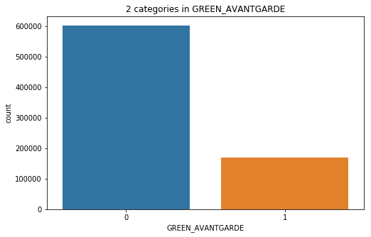

```
LP_FAMILIE_FEIN
```

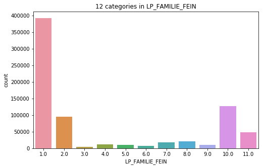

```
LP_FAMILIE_GROB
```

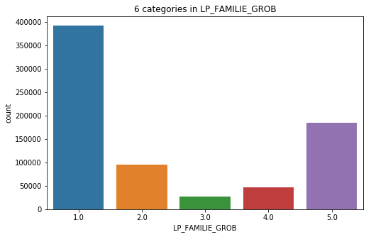

```
LP_STATUS_FEIN
```

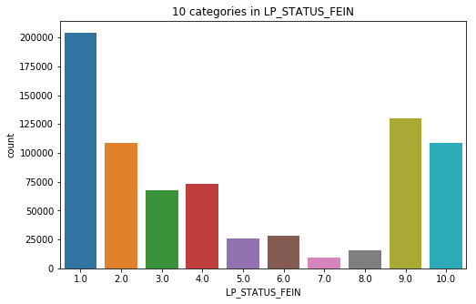

```
LP_STATUS_GROB
```

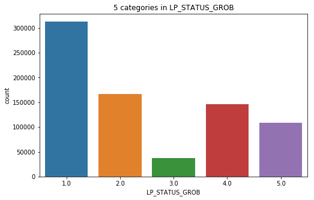

```
NATIONALITAET_KZ
```

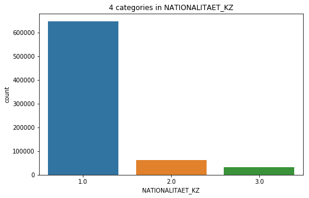

```
SHOPPER_TYP
```

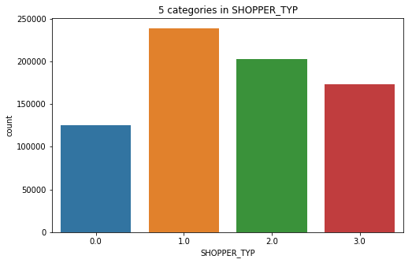

```
SOHO_KZ
```

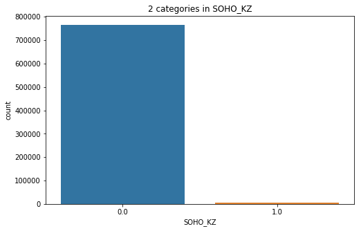

```
VERS_TYP
```

[6 more figures not shown]

```python
# Assess categorical variables: which are binary, which are multi-level, and
# which one needs to be re-encoded?
#azdias_low = azdias[missing_data_row<=threshold]

for val in cat_clms:
    print(val)
    plt.figure(figsize=(8,5))
    sns.countplot(x = val, data=azdias_low)
    plt.title('{} categories in {}'.format(len(azdias_low[val].unique()), val))
    plt.show()
```

```python
# Re-encode categorical variable(s) to be kept in the analysis.
for val in cat_clms:
    if len(azdias_low[val].unique()) > 2:
        dummies = pd.get_dummies(azdias_low[val], prefix=val)
        azdias_low.drop(val, axis=1, inplace=True)
        azdias_low = pd.concat([azdias_low, dummies], axis=1)
        print('One hot encoded {}'.format(val))
```

```
One hot encoded CJT_GESAMTTYP
One hot encoded FINANZTYP
One hot encoded GFK_URLAUBERTYP
One hot encoded LP_FAMILIE_FEIN
One hot encoded LP_FAMILIE_GROB
One hot encoded LP_STATUS_FEIN
One hot encoded LP_STATUS_GROB
One hot encoded NATIONALITAET_KZ
One hot encoded SHOPPER_TYP
One hot encoded VERS_TYP
One hot encoded ZABEOTYP
One hot encoded GEBAEUDETYP
One hot encoded CAMEO_DEUG_2015
One hot encoded CAMEO_DEU_2015
```

```python
pd.set_option('display.max_columns', 999)
azdias_low.head()
```

|  | ALTERSKATEGORIE_GROB | ANREDE_KZ | FINANZ_MINIMALIST | FINANZ_SPARER | FINANZ_VORSORGER | FINANZ_ANLEGER | FINANZ_UNAUFFAELLIGER | FINANZ_HAUSBAUER | GREEN_AVANTGARDE | HEALTH_TYP | LP_LEBENSPHASE_FEIN | LP_LEBENSPHASE_GROB | PRAEGENDE_JUGENDJAHRE | RETOURTYP_BK_S | SEMIO_SOZ | SEMIO_FAM | SEMIO_REL | SEMIO_MAT | SEMIO_VERT | SEMIO_LUST | SEMIO_ERL | SEMIO_KULT | SEMIO_RAT | SEMIO_KRIT | SEMIO_DOM | SEMIO_KAEM | SEMIO_PFLICHT | SEMIO_TRADV | SOHO_KZ | … |
| --- | --- | --- | --- | --- | --- | --- | --- | --- | --- | --- | --- | --- | --- | --- | --- | --- | --- | --- | --- | --- | --- | --- | --- | --- | --- | --- | --- | --- | --- | --- |
| 1 | 1.0 | 2 | 1 | 5 | 2 | 5 | 4 | 5 | 0 | 3.0 | 21.0 | 6.0 | 14.0 | 1.0 | 5 | 4 | 4 | 3 | 1 | 2 | 2 | 3 | 6 | 4 | 7 | 4 | 7 | 6 | 1.0 | … |
| 2 | 3.0 | 2 | 1 | 4 | 1 | 2 | 3 | 5 | 1 | 3.0 | 3.0 | 1.0 | 15.0 | 3.0 | 4 | 1 | 3 | 3 | 4 | 4 | 6 | 3 | 4 | 7 | 7 | 7 | 3 | 3 | 0.0 | … |
| 3 | 4.0 | 2 | 4 | 2 | 5 | 2 | 1 | 2 | 0 | 2.0 | NaN | NaN | 8.0 | 2.0 | 5 | 1 | 2 | 1 | 4 | 4 | 7 | 4 | 3 | 4 | 4 | 5 | 4 | 4 | 0.0 | … |
| 4 | 3.0 | 1 | 4 | 3 | 4 | 1 | 3 | 2 | 0 | 3.0 | 32.0 | 10.0 | 8.0 | 5.0 | 6 | 4 | 4 | 2 | 7 | 4 | 4 | 6 | 2 | 3 | 2 | 2 | 4 | 2 | 0.0 | … |
| 5 | 1.0 | 2 | 3 | 1 | 5 | 2 | 2 | 5 | 0 | 3.0 | 8.0 | 2.0 | 3.0 | 3.0 | 2 | 4 | 7 | 4 | 2 | 2 | 2 | 5 | 7 | 4 | 4 | 4 | 7 | 6 | 0.0 | … |

```python
#Need to encode 'OST_WEST_KZ' to replace 'O' and 'W' with 0 and 1 respectively
display(azdias_low['OST_WEST_KZ'].unique())
azdias_low.OST_WEST_KZ = azdias_low.OST_WEST_KZ.replace(['O','W'],[0,1])
display(azdias_low['OST_WEST_KZ'].unique())
```

```
array(['W', 'O'], dtype=object)
```

```
array([1, 0])
```

#### Discussion 1.2.1: Re-Encode Categorical Features

The binary numerical catergories have not been changed. The multi-level categories have been one hot encoded. Finally the column/feature 'OST_WEST_KZ' though binary was represented by 'O' and 'W. I have replaced these with 0 and 1 respectively.

#### Step 1.2.2: Engineer Mixed-Type Features

There are a handful of features that are marked as "mixed" in the feature summary that require special treatment in order to be included in the analysis. There are two in particular that deserve attention; the handling of the rest are up to your own choices:

- "PRAEGENDE_JUGENDJAHRE" combines information on three dimensions: generation by decade, movement (mainstream vs. avantgarde), and nation (east vs. west). While there aren't enough levels to disentangle east from west, you should create two new variables to capture the other two dimensions: an interval-type variable for decade, and a binary variable for movement.
- "CAMEO_INTL_2015" combines information on two axes: wealth and life stage. Break up the two-digit codes by their 'tens'-place and 'ones'-place digits into two new ordinal variables (which, for the purposes of this project, is equivalent to just treating them as their raw numeric values).
- If you decide to keep or engineer new features around the other mixed-type features, make sure you note your steps in the Discussion section.

Be sure to check `Data_Dictionary.md` for the details needed to finish these tasks.

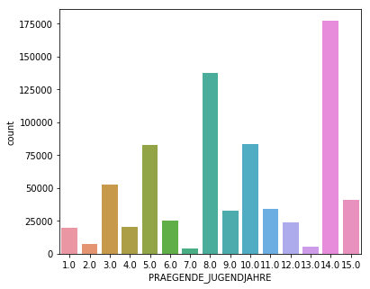

```python
# Investigate "PRAEGENDE_JUGENDJAHRE" and engineer two new variables.
plt.figure(figsize=(6,5))
sns.countplot(x = 'PRAEGENDE_JUGENDJAHRE', data=azdias_low)
plt.show()
```

```python
# Looking at PRAEGENDE_JUGENDJAHRE in the Data Dictionary shows that the data can be split along lines of years and movement
# East or West is ignored because it is not clear
# dictionaries with two new features
movement_dict = {1: 0.0, 2:1.0, 3:0.0, 4:1.0, 5:0.0, 6:1.0, 7:1.0, 8:0.0, 9:1.0, 10:0.0, 11:1.0, 12:0.0, 13:1.0, 14:0.0, 15:1.0}

years_dict = {1:40.0, 2:40.0, 3:50.0, 4:50.0, 5:60.0, 6:60.0, 7:60.0, 8:70.0, 9:70.0, 10:80.0, 11:80.0, 12:80.0,
    13:80.0, 14:90.0, 15:90.0}
```

```python
# adding the two new features to the dataframe
azdias_low['MOVEMENT'] = azdias_low['PRAEGENDE_JUGENDJAHRE'].map(movement_dict)
azdias_low['YEARS'] = azdias_low['PRAEGENDE_JUGENDJAHRE'].map(years_dict)
azdias_low[['PRAEGENDE_JUGENDJAHRE', 'MOVEMENT','YEARS']].head(12)
```

|  | PRAEGENDE_JUGENDJAHRE | MOVEMENT | YEARS |
| --- | --- | --- | --- |
| 1 | 14.0 | 0.0 | 90.0 |
| 2 | 15.0 | 1.0 | 90.0 |
| 3 | 8.0 | 0.0 | 70.0 |
| 4 | 8.0 | 0.0 | 70.0 |
| 5 | 3.0 | 0.0 | 50.0 |
| 6 | 10.0 | 0.0 | 80.0 |
| 7 | 8.0 | 0.0 | 70.0 |
| 8 | 11.0 | 1.0 | 80.0 |
| 9 | 15.0 | 1.0 | 90.0 |
| 10 | 3.0 | 0.0 | 50.0 |
| 12 | 8.0 | 0.0 | 70.0 |
| 13 | 15.0 | 1.0 | 90.0 |

```python
#dropping 'PRAEGENDE_JUGENDJAHRE' because it has been replaced by two new features
azdias_low.drop(['PRAEGENDE_JUGENDJAHRE'], axis=1, inplace = True)
azdias_low.shape
azdias_low.head()
```

|  | ALTERSKATEGORIE_GROB | ANREDE_KZ | FINANZ_MINIMALIST | FINANZ_SPARER | FINANZ_VORSORGER | FINANZ_ANLEGER | FINANZ_UNAUFFAELLIGER | FINANZ_HAUSBAUER | GREEN_AVANTGARDE | HEALTH_TYP | ... | CAMEO_DEU_2015_8B | CAMEO_DEU_2015_8C | CAMEO_DEU_2015_8D | CAMEO_DEU_2015_9A | CAMEO_DEU_2015_9B | CAMEO_DEU_2015_9C | CAMEO_DEU_2015_9D | CAMEO_DEU_2015_9E | MOVEMENT | YEARS |
| --- | --- | --- | --- | --- | --- | --- | --- | --- | --- | --- | --- | --- | --- | --- | --- | --- | --- | --- | --- | --- | --- |
| 1 | 1.0 | 2 | 1 | 5 | 2 | 5 | 4 | 5 | 0 | 3.0 | ... | 0 | 0 | 0 | 0 | 0 | 0 | 0 | 0 | 0.0 | 90.0 |
| 2 | 3.0 | 2 | 1 | 4 | 1 | 2 | 3 | 5 | 1 | 3.0 | ... | 0 | 0 | 0 | 0 | 0 | 0 | 0 | 0 | 1.0 | 90.0 |
| 3 | 4.0 | 2 | 4 | 2 | 5 | 2 | 1 | 2 | 0 | 2.0 | ... | 0 | 0 | 0 | 0 | 0 | 0 | 0 | 0 | 0.0 | 70.0 |
| 4 | 3.0 | 1 | 4 | 3 | 4 | 1 | 3 | 2 | 0 | 3.0 | ... | 0 | 0 | 0 | 0 | 0 | 0 | 0 | 0 | 0.0 | 70.0 |
| 5 | 1.0 | 2 | 3 | 1 | 5 | 2 | 2 | 5 | 0 | 3.0 | ... | 0 | 1 | 0 | 0 | 0 | 0 | 0 | 0 | 0.0 | 50.0 |

5 rows × 196 columns

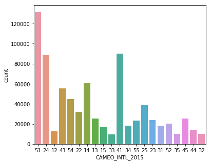

```python
# Investigate "CAMEO_INTL_2015" and engineer two new variables.
plt.figure(figsize=(6,5))
sns.countplot(x = 'CAMEO_INTL_2015', data=azdias_low)
plt.show()
```

```python
'''
German CAMEO: Wealth / Life Stage Typology, mapped to international code
- -1: unknown
- 11: Wealthy Households - Pre-Family Couples & Singles
- 12: Wealthy Households - Young Couples With Children
- 13: Wealthy Households - Families With School Age Children
- 14: Wealthy Households - Older Families &  Mature Couples
- 15: Wealthy Households - Elders In Retirement
- 21: Prosperous Households - Pre-Family Couples & Singles
- 22: Prosperous Households - Young Couples With Children
- 23: Prosperous Households - Families With School Age Children
- 24: Prosperous Households - Older Families & Mature Couples
- 25: Prosperous Households - Elders In Retirement
- 31: Comfortable Households - Pre-Family Couples & Singles
- 32: Comfortable Households - Young Couples With Children
- 33: Comfortable Households - Families With School Age Children
- 34: Comfortable Households - Older Families & Mature Couples
- 35: Comfortable Households - Elders In Retirement
- 41: Less Affluent Households - Pre-Family Couples & Singles
- 42: Less Affluent Households - Young Couples With Children
- 43: Less Affluent Households - Families With School Age Children
- 44: Less Affluent Households - Older Families & Mature Couples
- 45: Less Affluent Households - Elders In Retirement
- 51: Poorer Households - Pre-Family Couples & Singles
- 52: Poorer Households - Young Couples With Children
- 53: Poorer Households - Families With School Age Children
- 54: Poorer Households - Older Families & Mature Couples
- 55: Poorer Households - Elders In Retirement
- XX: unknown
'''
```

```python
# closer inspection of CAMEO_INTL_2015 shows that it is essentially combinations of economic status and family stage.

azdias_low['ECON_STATUS'] = azdias_low['CAMEO_INTL_2015'].apply(lambda val: val[0] if not pd.isnull(val) else np.NaN)
azdias_low['FAM_STAGE'] = azdias_low['CAMEO_INTL_2015'].apply(lambda val: val[1] if not pd.isnull(val) else np.NaN)
azdias_low[['CAMEO_INTL_2015','ECON_STATUS','FAM_STAGE']].head(10)
```

|  | CAMEO_INTL_2015 | ECON_STATUS | FAM_STAGE |
| --- | --- | --- | --- |
| 1 | 51 | 5 | 1 |
| 2 | 24 | 2 | 4 |
| 3 | 12 | 1 | 2 |
| 4 | 43 | 4 | 3 |
| 5 | 54 | 5 | 4 |
| 6 | 22 | 2 | 2 |
| 7 | 14 | 1 | 4 |
| 8 | 13 | 1 | 3 |
| 9 | 15 | 1 | 5 |
| 10 | 51 | 5 | 1 |

```python
# delete 'CAMEO_INTL_2015' feature as it has been replaced by the two new features
azdias_low.drop('CAMEO_INTL_2015', axis=1, inplace=True)
azdias_low.head()
```

|  | ALTERSKATEGORIE_GROB | ANREDE_KZ | FINANZ_MINIMALIST | FINANZ_SPARER | FINANZ_VORSORGER | FINANZ_ANLEGER | FINANZ_UNAUFFAELLIGER | FINANZ_HAUSBAUER | GREEN_AVANTGARDE | HEALTH_TYP | ... | CAMEO_DEU_2015_8D | CAMEO_DEU_2015_9A | CAMEO_DEU_2015_9B | CAMEO_DEU_2015_9C | CAMEO_DEU_2015_9D | CAMEO_DEU_2015_9E | MOVEMENT | YEARS | ECON_STATUS | FAM_STAGE |
| --- | --- | --- | --- | --- | --- | --- | --- | --- | --- | --- | --- | --- | --- | --- | --- | --- | --- | --- | --- | --- | --- |
| 1 | 1.0 | 2 | 1 | 5 | 2 | 5 | 4 | 5 | 0 | 3.0 | ... | 0 | 0 | 0 | 0 | 0 | 0 | 0.0 | 90.0 | 5 | 1 |
| 2 | 3.0 | 2 | 1 | 4 | 1 | 2 | 3 | 5 | 1 | 3.0 | ... | 0 | 0 | 0 | 0 | 0 | 0 | 1.0 | 90.0 | 2 | 4 |
| 3 | 4.0 | 2 | 4 | 2 | 5 | 2 | 1 | 2 | 0 | 2.0 | ... | 0 | 0 | 0 | 0 | 0 | 0 | 0.0 | 70.0 | 1 | 2 |
| 4 | 3.0 | 1 | 4 | 3 | 4 | 1 | 3 | 2 | 0 | 3.0 | ... | 0 | 0 | 0 | 0 | 0 | 0 | 0.0 | 70.0 | 4 | 3 |
| 5 | 1.0 | 2 | 3 | 1 | 5 | 2 | 2 | 5 | 0 | 3.0 | ... | 0 | 0 | 0 | 0 | 0 | 0 | 0.0 | 50.0 | 5 | 4 |

5 rows × 197 columns

#### Discussion 1.2.2: Engineer Mixed-Type Features

The two mixed type features of 'CAMEO_INTL_2015' and 'PRAEGENDE_JUGENDJAHRE' were studied and I found that they could be represented more efficiently be introduction of two new features each. For 'PRAEGENDE_JUGENDJAHRE', the two new features are 'MOVEMENT' and 'YEARS' while for 'CAMEO_INTL_2015', the two new features are 'ECON_STATUS' and 'FAM_STAGE'. The old features were dropped.

#### Step 1.2.3: Complete Feature Selection

In order to finish this step up, you need to make sure that your data frame now only has the columns that you want to keep. To summarize, the dataframe should consist of the following:

- All numeric, interval, and ordinal type columns from the original dataset.
- Binary categorical features (all numerically-encoded).
- Engineered features from other multi-level categorical features and mixed features.

Make sure that for any new columns that you have engineered, that you've excluded the original columns from the final dataset. Otherwise, their values will interfere with the analysis later on the project. For example, you should not keep "PRAEGENDE_JUGENDJAHRE", since its values won't be useful for the algorithm: only the values derived from it in the engineered features you created should be retained. As a reminder, your data should only be from **the subset with few or no missing values**.

```python
# Do whatever you need to do in order to ensure that the dataframe only contains
# the columns that should be passed to the algorithm functions.

# These are the features of type 'mixed' but two of them 'PRAEGENDE_JUGENDJAHRE' and 'CAMEO_INTL_2015'
# have already been dealt with

feat_info[feat_info.type =='mixed']
```

|  | attribute | information_level | type | missing_or_unknown |
| --- | --- | --- | --- | --- |
| 15 | LP_LEBENSPHASE_FEIN | person | mixed | [0] |
| 16 | LP_LEBENSPHASE_GROB | person | mixed | [0] |
| 22 | PRAEGENDE_JUGENDJAHRE | person | mixed | [-1,0] |
| 56 | WOHNLAGE | building | mixed | [-1] |
| 59 | CAMEO_INTL_2015 | microcell_rr4 | mixed | [-1,XX] |
| 64 | KBA05_BAUMAX | microcell_rr3 | mixed | [-1,0] |
| 79 | PLZ8_BAUMAX | macrocell_plz8 | mixed | [-1,0] |

```python
#delete WOHNLAGE because it does not add much value after PCA Analysis (made decision after running PCA once)
azdias_low.drop(['WOHNLAGE'], axis=1, inplace=True)

#delete PLZ8_BAUMAX because it almost fully overlapped by PLZ8_ANTG1
azdias_low.drop(['PLZ8_BAUMAX'], axis=1, inplace=True)
azdias_low.head()
```

|  | ALTERSKATEGORIE_GROB | ANREDE_KZ | FINANZ_MINIMALIST | FINANZ_SPARER | FINANZ_VORSORGER | FINANZ_ANLEGER | FINANZ_UNAUFFAELLIGER | FINANZ_HAUSBAUER | GREEN_AVANTGARDE | HEALTH_TYP | ... | CAMEO_DEU_2015_8D | CAMEO_DEU_2015_9A | CAMEO_DEU_2015_9B | CAMEO_DEU_2015_9C | CAMEO_DEU_2015_9D | CAMEO_DEU_2015_9E | MOVEMENT | YEARS | ECON_STATUS | FAM_STAGE |
| --- | --- | --- | --- | --- | --- | --- | --- | --- | --- | --- | --- | --- | --- | --- | --- | --- | --- | --- | --- | --- | --- |
| 1 | 1.0 | 2 | 1 | 5 | 2 | 5 | 4 | 5 | 0 | 3.0 | ... | 0 | 0 | 0 | 0 | 0 | 0 | 0.0 | 90.0 | 5 | 1 |
| 2 | 3.0 | 2 | 1 | 4 | 1 | 2 | 3 | 5 | 1 | 3.0 | ... | 0 | 0 | 0 | 0 | 0 | 0 | 1.0 | 90.0 | 2 | 4 |
| 3 | 4.0 | 2 | 4 | 2 | 5 | 2 | 1 | 2 | 0 | 2.0 | ... | 0 | 0 | 0 | 0 | 0 | 0 | 0.0 | 70.0 | 1 | 2 |
| 4 | 3.0 | 1 | 4 | 3 | 4 | 1 | 3 | 2 | 0 | 3.0 | ... | 0 | 0 | 0 | 0 | 0 | 0 | 0.0 | 70.0 | 4 | 3 |
| 5 | 1.0 | 2 | 3 | 1 | 5 | 2 | 2 | 5 | 0 | 3.0 | ... | 0 | 0 | 0 | 0 | 0 | 0 | 0.0 | 50.0 | 5 | 4 |

5 rows × 195 columns

### Step 1.3: Create a Cleaning Function

Even though you've finished cleaning up the general population demographics data, it's important to look ahead to the future and realize that you'll need to perform the same cleaning steps on the customer demographics data. In this substep, complete the function below to execute the main feature selection, encoding, and re-engineering steps you performed above. Then, when it comes to looking at the customer data in Step 3, you can just run this function on that DataFrame to get the trimmed dataset in a single step.

```python
def clean_data(df1):
    """
    Perform feature trimming, re-encoding, and engineering for demographics
    data

    INPUT: Demographics DataFrame
    OUTPUT: Trimmed and cleaned demographics DataFrame
    """

    # Put in code here to execute all main cleaning steps:
    # convert missing value codes into NaNs, ..................................
    print('Converting missing value codes to Nans.........')

    for i in range(df1.shape[1]):
        clm = feat_info['attribute'].iloc[i]
        missing_lst = feat_info['missing_or_unknown'].iloc[i]
        missing_lst = missing_lst.split(',')

        if missing_lst != '':

            for val in missing_lst:
                val = val.strip('[')
                val = val.strip(']')

                try:
                    val = int(val)
                except:
                    pass

                df1[clm].replace(val,np.NaN, inplace = True)


    # remove selected columns and rows, ...............................................
    print("Deleting columns with more than 20% missing data")

    # remove columns ********
    dropped_clms = ['TITEL_KZ', 'AGER_TYP', 'KK_KUNDENTYP', 'KBA05_BAUMAX', 'GEBURTSJAHR','ALTER_HH']
    display(dropped_clms)

    for clm in dropped_clms:
        df1.drop(clm, axis=1, inplace=True)

    # ********* remove rows *********
    print("Removing rows with more than 10 missing features ....")

    missing_data_row = df1.isna().sum(axis=1)
    threshold = 10
    # remain with only those columns with less than 8 missing feature values
    df = df1[missing_data_row<=threshold]
    df2 = df1[missing_data_row>threshold]

    # ........ select, re-encode, and engineer column values.............................
    new_feat_info = feat_info.copy()

    for val in dropped_clms:
        test = new_feat_info[feat_info.attribute == val].index
        new_feat_info.drop(test, inplace=True)

    cat_clms = new_feat_info[(new_feat_info.type=='categorical').values].attribute.values

    # if there are more 2 features, one hot encode it
    for val in cat_clms:
        if len(df[val].unique()) > 2:
            dummies = pd.get_dummies(df[val], prefix=val)
            df.drop(val, axis=1, inplace=True)
            df = pd.concat([df, dummies], axis=1)
            print('One hot encoded {}'.format(val))

    # feature engineering for columns with mixed features...................................
    print('Feature engineering for columns of type: mixed.......')
    feat_info[feat_info.type =='mixed']

    # dicts for the two new features of 'PRAEGENDE_JUGENDJAHRE'
    movement_dict = {1: 0.0, 2:1.0, 3:0.0, 4:1.0, 5:0.0, 6:1.0, 7:1.0, 8:0.0, 9:1.0, 10:0.0, 11:1.0, 12:0.0, 13:1.0, 14:0.0, 15:1.0}

    years_dict = {1:40.0, 2:40.0, 3:50.0, 4:50.0, 5:60.0, 6:60.0, 7:60.0, 8:70.0, 9:70.0, 10:80.0, 11:80.0, 12:80.0,
    13:80.0, 14:90.0, 15:90.0}

    df['MOVEMENT'] = df['PRAEGENDE_JUGENDJAHRE'].map(movement_dict)
    df['YEARS'] = df['PRAEGENDE_JUGENDJAHRE'].map(years_dict)
    df.drop(['PRAEGENDE_JUGENDJAHRE'], axis=1, inplace = True)

    # feature engineering for 'CAMEO_INTL_2015'
    df['ECON_STATUS'] = df['CAMEO_INTL_2015'].apply(lambda val: val[0] if not pd.isnull(val) else np.NaN)
    df['FAM_STAGE'] = df['CAMEO_INTL_2015'].apply(lambda val: val[1] if not pd.isnull(val) else np.NaN)
    df.drop('CAMEO_INTL_2015', axis=1, inplace=True)


    # replace 'O' and 'W' in OST_WEST_KZ feature with 0 and 1 respectively
    df.OST_WEST_KZ = df.OST_WEST_KZ.replace(['O','W'],[0,1])

    #delete WOHNLAGE because it does not add much value after PCA Analysis (made decision after running PCA once)
    df.drop(['WOHNLAGE'], axis=1, inplace=True)
    print('Dropping WOHNLAGE .....')

    #delete PLZ8_BAUMAX because it almost fully overlapped by PLZ8_ANTG1
    df.drop(['PLZ8_BAUMAX'], axis=1, inplace=True)
    print('Dropping PLZ8_BAUMAX .....')

    # Return the cleaned dataframe.
    return df, df2
```

```python
#pd.set_option('display.max_columns', 999)
azdias_low.head()
```

|  | ALTERSKATEGORIE_GROB | ANREDE_KZ | FINANZ_MINIMALIST | FINANZ_SPARER | FINANZ_VORSORGER | FINANZ_ANLEGER | FINANZ_UNAUFFAELLIGER | FINANZ_HAUSBAUER | GREEN_AVANTGARDE | HEALTH_TYP | LP_LEBENSPHASE_FEIN | LP_LEBENSPHASE_GROB | RETOURTYP_BK_S | SEMIO_SOZ | SEMIO_FAM | SEMIO_REL | SEMIO_MAT | SEMIO_VERT | SEMIO_LUST | SEMIO_ERL | SEMIO_KULT | SEMIO_RAT | SEMIO_KRIT | SEMIO_DOM | SEMIO_KAEM | SEMIO_PFLICHT | SEMIO_TRADV | SOHO_KZ | ANZ_PERSONEN | … |
| --- | --- | --- | --- | --- | --- | --- | --- | --- | --- | --- | --- | --- | --- | --- | --- | --- | --- | --- | --- | --- | --- | --- | --- | --- | --- | --- | --- | --- | --- | --- |
| 1 | 1.0 | 2 | 1 | 5 | 2 | 5 | 4 | 5 | 0 | 3.0 | 21.0 | 6.0 | 1.0 | 5 | 4 | 4 | 3 | 1 | 2 | 2 | 3 | 6 | 4 | 7 | 4 | 7 | 6 | 1.0 | 2.0 | … |
| 2 | 3.0 | 2 | 1 | 4 | 1 | 2 | 3 | 5 | 1 | 3.0 | 3.0 | 1.0 | 3.0 | 4 | 1 | 3 | 3 | 4 | 4 | 6 | 3 | 4 | 7 | 7 | 7 | 3 | 3 | 0.0 | 1.0 | … |
| 3 | 4.0 | 2 | 4 | 2 | 5 | 2 | 1 | 2 | 0 | 2.0 | NaN | NaN | 2.0 | 5 | 1 | 2 | 1 | 4 | 4 | 7 | 4 | 3 | 4 | 4 | 5 | 4 | 4 | 0.0 | 0.0 | … |
| 4 | 3.0 | 1 | 4 | 3 | 4 | 1 | 3 | 2 | 0 | 3.0 | 32.0 | 10.0 | 5.0 | 6 | 4 | 4 | 2 | 7 | 4 | 4 | 6 | 2 | 3 | 2 | 2 | 4 | 2 | 0.0 | 4.0 | … |
| 5 | 1.0 | 2 | 3 | 1 | 5 | 2 | 2 | 5 | 0 | 3.0 | 8.0 | 2.0 | 3.0 | 2 | 4 | 7 | 4 | 2 | 2 | 2 | 5 | 7 | 4 | 4 | 4 | 7 | 6 | 0.0 | 1.0 | … |

## Step 2: Feature Transformation

### Step 2.1: Apply Feature Scaling

Before we apply dimensionality reduction techniques to the data, we need to perform feature scaling so that the principal component vectors are not influenced by the natural differences in scale for features. Starting from this part of the project, you'll want to keep an eye on the [API reference page for sklearn](http://scikit-learn.org/stable/modules/classes.html) to help you navigate to all of the classes and functions that you'll need. In this substep, you'll need to check the following:

- sklearn requires that data not have missing values in order for its estimators to work properly. So, before applying the scaler to your data, make sure that you've cleaned the DataFrame of the remaining missing values. This can be as simple as just removing all data points with missing data, or applying an [Imputer](http://scikit-learn.org/stable/modules/generated/sklearn.preprocessing.Imputer.html) to replace all missing values. You might also try a more complicated procedure where you temporarily remove missing values in order to compute the scaling parameters before re-introducing those missing values and applying imputation. Think about how much missing data you have and what possible effects each approach might have on your analysis, and justify your decision in the discussion section below.
- For the actual scaling function, a [StandardScaler](http://scikit-learn.org/stable/modules/generated/sklearn.preprocessing.StandardScaler.html) instance is suggested, scaling each feature to mean 0 and standard deviation 1.
- For these classes, you can make use of the `.fit_transform()` method to both fit a procedure to the data as well as apply the transformation to the data at the same time. Don't forget to keep the fit sklearn objects handy, since you'll be applying them to the customer demographics data towards the end of the project.

```python
# If you've not yet cleaned the dataset of all NaN values, then investigate and
# do that now.

azdias_test = azdias_low.copy()
azdias_low = azdias_test.copy()

impute = Imputer(missing_values = np.nan, strategy='median')

azdias_new = pd.DataFrame(impute.fit_transform(azdias_low))
azdias_new.columns = azdias_low.columns
azdias_new.index = azdias_low.index
```

```python
azdias_new.head()
azdias_new.isna().sum().sum()
```

```
0
```

```python
# Apply feature scaling to the general population demographics data.

scaler = StandardScaler()
azdias_scaled = pd.DataFrame(scaler.fit_transform(azdias_new))
azdias_scaled.columns = azdias_new.columns
azdias_scaled.index = azdias_new.index
```

```python
azdias_scaled.head()
```

|  | ALTERSKATEGORIE_GROB | ANREDE_KZ | FINANZ_MINIMALIST | FINANZ_SPARER | FINANZ_VORSORGER | FINANZ_ANLEGER | FINANZ_UNAUFFAELLIGER | FINANZ_HAUSBAUER | GREEN_AVANTGARDE | HEALTH_TYP | ... | CAMEO_DEU_2015_8D | CAMEO_DEU_2015_9A | CAMEO_DEU_2015_9B | CAMEO_DEU_2015_9C | CAMEO_DEU_2015_9D | CAMEO_DEU_2015_9E | MOVEMENT | YEARS | ECON_STATUS | FAM_STAGE |
| --- | --- | --- | --- | --- | --- | --- | --- | --- | --- | --- | --- | --- | --- | --- | --- | --- | --- | --- | --- | --- | --- |
| 1 | -1.764603 | 0.959073 | -1.488002 | 1.539656 | -1.043931 | 1.468403 | 0.981832 | 1.326992 | -0.531851 | 1.086177 | ... | -0.151375 | -0.163979 | -0.191551 | -0.181668 | -0.194505 | -0.088201 | -0.531851 | 1.174022 | 1.176214 | -1.259551 |
| 2 | 0.199826 | 0.959073 | -1.488002 | 0.866704 | -1.769993 | -0.569520 | 0.264219 | 1.326992 | 1.880228 | 1.086177 | ... | -0.151375 | -0.163979 | -0.191551 | -0.181668 | -0.194505 | -0.088201 | 1.880228 | 1.174022 | -0.874424 | 0.760685 |
| 3 | 1.182040 | 0.959073 | 0.690044 | -0.479200 | 1.134255 | -0.569520 | -1.171006 | -0.819321 | -0.531851 | -0.264810 | ... | -0.151375 | -0.163979 | -0.191551 | -0.181668 | -0.194505 | -0.088201 | -0.531851 | -0.218770 | -1.557970 | -0.586139 |
| 4 | 0.199826 | -1.042673 | 0.690044 | 0.193752 | 0.408193 | -1.248828 | 0.264219 | -0.819321 | -0.531851 | 1.086177 | ... | -0.151375 | -0.163979 | -0.191551 | -0.181668 | -0.194505 | -0.088201 | -0.531851 | -0.218770 | 0.492668 | 0.087273 |
| 5 | -1.764603 | 0.959073 | -0.035971 | -1.152152 | 1.134255 | -0.569520 | -0.453393 | 1.326992 | -0.531851 | 1.086177 | ... | -0.151375 | -0.163979 | -0.191551 | -0.181668 | -0.194505 | -0.088201 | -0.531851 | -1.611563 | 1.176214 | 0.760685 |

5 rows × 195 columns

### Discussion 2.1: Apply Feature Scaling

After the imputation was done, the data was scaled using the Standard Scaler. This is to ensure that features with large or values do not unduly bias the clustering algorithm and those that are very small are not ignored. Therefore at the end of this scaling all features are on the same scale.